# Randomization: Applications

## Hypothesis testing by randomization

[figure not shown]

## Hypothesis testing by randomization

Mandible lengths of female and male jackals from the Natural History Museum (London).

```r
M <- read_excel("../data/Jackals.xlsx")
glimpse(M)
```

```
## Observations: 20
## Variables: 2
## $ Mandible <dbl> 110, 111, 107, 108, 110, 105, 107, 106, 111, 111, 120, …
## $ Sex      <chr> "F", "F", "F", "F", "F", "F", "F", "F", "F", "F", "M", …
```

```r
M <- M %>% mutate(Sex = factor(Sex)) %>% as.data.frame()
```

## Randomization tests

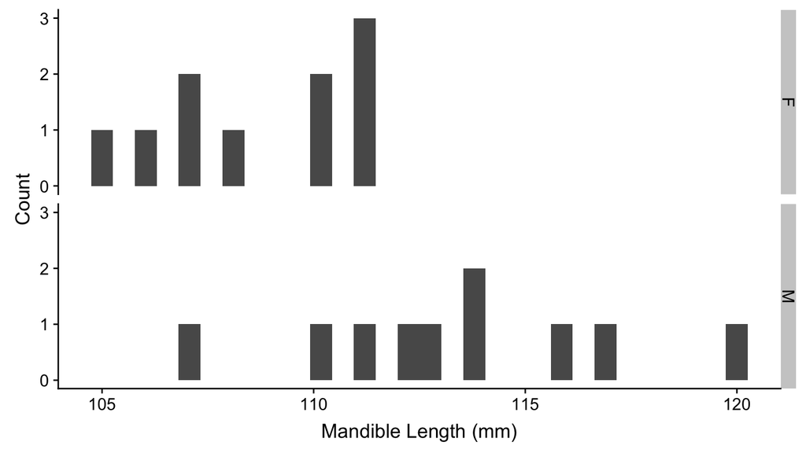

## Randomization tests

We’d like to do a *t*-test to compare group means.

But:

1. Assumes random sampling
2. Assumes equal group variances
3. Assumes normal distribution within groups

## Basic randomization procedure

1. Decide on a test statistic
2. Calculate the test statistic for the *observed* data
3. Randomly shuffle the observations
4. Calculate the test statistic for that group
5. Repeat thousands of times
6. Determine the proportion of random combinations resulting in a test statistic more extreme than the observed value (“empirical *P*”)

When test assumptions are met, the results will match asymptotic procedures. When the assumptions are not met, the results will be valid.

## Decide on a test statistic

1. Mean difference
2. *t*: *t*-test, linear model parameter estimate (slope, intercept)
3. *F*: ANOVA-like
4. \(\chi^2\)
5. Any metric of your choice (P-value, Fst, heterozygosity, LOD score, etc.)

## Calculate the test statistic for the observed data

Observed difference in mean value for females vs. males:

```r
(obs <- mean(M$Mandible[M$Sex == "F"]) -
   mean(M$Mandible[M$Sex == "M"]))
```

```
## [1] -4.8
```

## Randomly reassign, recalculate, repeat

```r
# Set random number seed
set.seed(10)

nreps <- 1e4
diffs <- numeric(length = nreps)
diffs[1] <- obs
for (ii in 2:nreps) {
  Rand_Sex <- sample(M$Sex)
  diffs[ii] <- mean(M$Mandible[Rand_Sex == "F"]) -
    mean(M$Mandible[Rand_Sex == "M"])
}
```

## Visualize the results

```r
ggplot(data.frame(diffs), aes(diffs)) +
  geom_histogram(bins = 25) +
  geom_vline(xintercept = diffs[1], color = "red") +
  labs(x = "Difference", y = "Count")
```

Histogram of the randomized differences, vertical red line to mark the observed value.

## Visualize the results

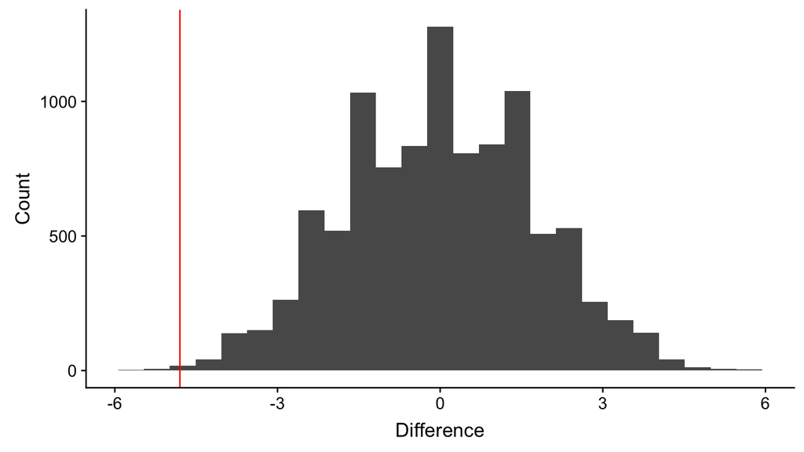

## Proportion of randomized differences more extreme than the observed

```r
mean(diffs <= diffs[1])
```

```
## [1] 0.0013
```

Mean of `diffs` where the value is *less than or equal to* the observed mean difference.

Empirically determined *P*-value is 0.0013.

```r
mean(c(TRUE, TRUE, FALSE))
```

```
## [1] 0.6666667
```

## Randomization using R functions

- Run the test as usual, save the result to an object
- Extract the value of the test statistic
  - `str()`
  - `summary()`

## Finding the test statistic

```r
obs <- t.test(Mandible ~ Sex, data = M)
obs
```

```
##
##  Welch Two Sample t-test
##
## data:  Mandible by Sex
## t = -3.4843, df = 14.894, p-value = 0.00336
## alternative hypothesis: true difference in means is not equal to 0
## 95 percent confidence interval:
##  -7.738105 -1.861895
## sample estimates:
## mean in group F mean in group M
##           108.6           113.4
```

## Finding the test statistic

```r
str(obs)
```

```
## List of 9
##  $ statistic  : Named num -3.48
##   ..- attr(*, "names")= chr "t"
##  $ parameter  : Named num 14.9
##   ..- attr(*, "names")= chr "df"
##  $ p.value    : num 0.00336
##  $ conf.int   : num [1:2] -7.74 -1.86
##   ..- attr(*, "conf.level")= num 0.95
##  $ estimate   : Named num [1:2] 109 113
##   ..- attr(*, "names")= chr [1:2] "mean in group F" "mean in group M"
##  $ null.value : Named num 0
##   ..- attr(*, "names")= chr "difference in means"
##  $ alternative: chr "two.sided"
##  $ method     : chr "Welch Two Sample t-test"
##  $ data.name  : chr "Mandible by Sex"
##  - attr(*, "class")= chr "htest"
```

## Randomization using a *t*-test

```r
set.seed(8987324)
nreps <- 1e4
t_stats <- numeric(nreps)
t_stats[1] <- t.test(Mandible ~ Sex, data = M)$statistic

for (ii in 2:nreps) {
  t_stats[ii] <- t.test(sample(Mandible) ~ Sex, data = M)$statistic
}
```

`t.test(Mandible ~ Sex, data = M)$statistic` returns only the *t*-statistic.

## Visualize the results

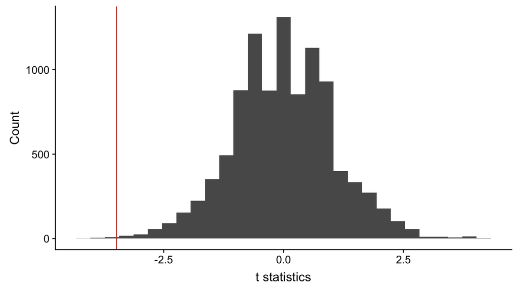

## Proportion of randomized *t* more extreme than the observed

```r
2 * mean(t_stats <= t_stats[1])
```

```
## [1] 0.0028
```

Empirical *P* value is 0.0028 (*two-tailed test*).

## Use an *F*-test

```r
tic <- Sys.time()

set.seed(432431)
nreps <- 1e4
F_stats <- numeric(nreps)
obs_lm <- lm(Mandible ~ Sex, data = M)
obs_F <- anova(obs_lm)$"F value"[1]
F_stats[1] <- obs_F

for (ii in 2:nreps) {
  rand_lm <- lm(sample(Mandible) ~ Sex, data = M)
  rand_F <- anova(rand_lm)$"F value"[1]
  F_stats[ii] <- rand_F
}

toc <- Sys.time()
```

## Finding *F*

```r
str(anova(obs_lm))
```

```
## Classes 'anova' and 'data.frame':    2 obs. of  5 variables:
##  $ Df     : int  1 18
##  $ Sum Sq : num  115 171
##  $ Mean Sq: num  115.2 9.49
##  $ F value: num  12.1 NA
##  $ Pr(>F) : num  0.00265 NA
##  - attr(*, "heading")= chr  "Analysis of Variance Table\n" "Response: Mandible"
```

## Visualize the results

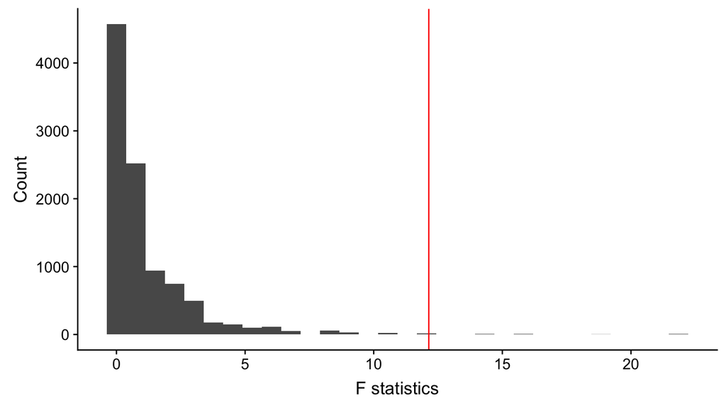

## Proportion of randomized *F* more extreme than the observed

```r
mean(F_stats >= F_stats[1])
```

```
## [1] 0.0031
```

Empirical *P* value is 0.0031. No need to double here, because of the shape of the *F* distribution

## Randomization or permutation?

We have randomly sampled 10,000 possible combinations (some of which may have repeated).

We could permute all 184,756 combinations of 20 items taken 10 at a time (`choose(20, 10)`) with a little time. 10,000 combinations took:

```r
toc - tic
```

```
## Time difference of 15.15694 secs
```

With larger sample sizes, permutation is not feasible.

## Example: Age predicted by coloration in lion noses

[figure not shown]

## Age predicted by coloration in lion noses

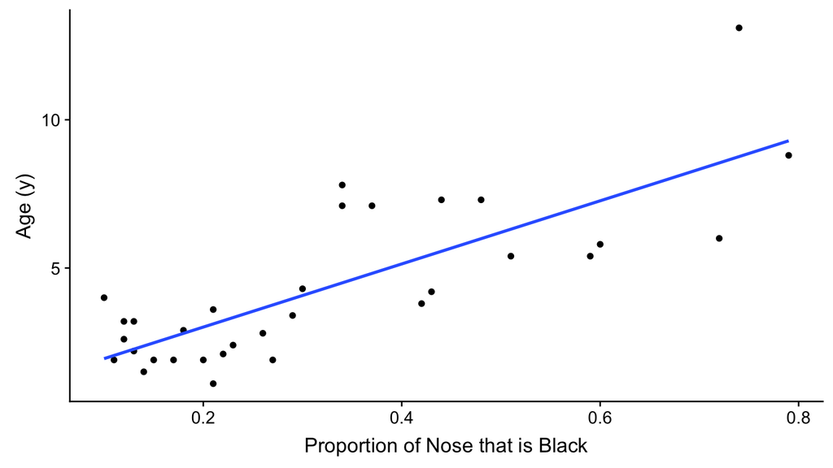

## Age predicted by nose coloration

```r
fm <- lm(age ~ proportion.black, data = LionNoses)
summary(fm)
```

```
##
## Call:
## lm(formula = age ~ proportion.black, data = LionNoses)
##
## Residuals:
##     Min      1Q  Median      3Q     Max
## -2.5449 -1.1117 -0.5285  0.9635  4.3421
##
## Coefficients:
##                  Estimate Std. Error t value Pr(>|t|)
## (Intercept)        0.8790     0.5688   1.545    0.133
## proportion.black  10.6471     1.5095   7.053 7.68e-08 ***
## ---
## Signif. codes:  0 '***' 0.001 '**' 0.01 '*' 0.05 '.' 0.1 ' ' 1
##
## Residual standard error: 1.669 on 30 degrees of freedom
## Multiple R-squared:  0.6238, Adjusted R-squared:  0.6113
## F-statistic: 49.75 on 1 and 30 DF,  p-value: 7.677e-08
```

## Age predicted by nose coloration

```r
str(summary(fm))
```

```
## List of 11
##  $ call         : language lm(formula = age ~ proportion.black, data = LionNoses)
##  $ terms        :Classes 'terms', 'formula'  language age ~ proportion.black
##   .. ..- attr(*, "variables")= language list(age, proportion.black)
##   .. ..- attr(*, "factors")= int [1:2, 1] 0 1
##   .. .. ..- attr(*, "dimnames")=List of 2
##   .. .. .. ..$ : chr [1:2] "age" "proportion.black"
##   .. .. .. ..$ : chr "proportion.black"
##   .. ..- attr(*, "term.labels")= chr "proportion.black"
##   .. ..- attr(*, "order")= int 1
##   .. ..- attr(*, "intercept")= int 1
##   .. ..- attr(*, "response")= int 1
##   .. ..- attr(*, ".Environment")=<environment: R_GlobalEnv>
##   .. ..- attr(*, "predvars")= language list(age, proportion.black)
##   .. ..- attr(*, "dataClasses")= Named chr [1:2] "numeric" "numeric"
##   .. .. ..- attr(*, "names")= chr [1:2] "age" "proportion.black"
##  $ residuals    : Named num [1:32] -2.0149 -0.8696 -0.1502 -0.0631 0.4433 ...
##   ..- attr(*, "names")= chr [1:32] "1" "2" "3" "4" ...
##  $ coefficients : num [1:2, 1:4] 0.879 10.647 0.569 1.51 1.545 ...
##   ..- attr(*, "dimnames")=List of 2
##   .. ..$ : chr [1:2] "(Intercept)" "proportion.black"
##   .. ..$ : chr [1:4] "Estimate" "Std. Error" "t value" "Pr(>|t|)"
##  $ aliased      : Named logi [1:2] FALSE FALSE
##   ..- attr(*, "names")= chr [1:2] "(Intercept)" "proportion.black"
##  $ sigma        : num 1.67
##  $ df           : int [1:3] 2 30 2
##  $ r.squared    : num 0.624
##  $ adj.r.squared: num 0.611
##  $ fstatistic   : Named num [1:3] 49.8 1 30
##   ..- attr(*, "names")= chr [1:3] "value" "numdf" "dendf"
##  $ cov.unscaled : num [1:2, 1:2] 0.116 -0.264 -0.264 0.818
##   ..- attr(*, "dimnames")=List of 2
##   .. ..$ : chr [1:2] "(Intercept)" "proportion.black"
##   .. ..$ : chr [1:2] "(Intercept)" "proportion.black"
##  - attr(*, "class")= chr "summary.lm"
```

## Age predicted by nose coloration

```r
summary(fm)$coefficients
```

```
##                    Estimate Std. Error  t value     Pr(>|t|)
## (Intercept)       0.8790062  0.5688171 1.545323 1.327530e-01
## proportion.black 10.6471194  1.5095005 7.053406 7.677005e-08
```

```r
summary(fm)$coefficients[2, 3]
```

```
## [1] 7.053406
```

## Age predicted by nose coloration

```r
set.seed(481769)
nreps <- 1e4
t_stats <- numeric(nreps)
t_stats[1] <- summary(fm)$coefficients[2, 3]

for (ii in 2:nreps) {
  Rand_Age <- sample(LionNoses$age)
  fm_rand <- lm(Rand_Age ~ proportion.black, data = LionNoses)
  t_stats[ii] <- summary(fm_rand)$coefficients[2, 3]
}
```

## Age predicted by nose coloration

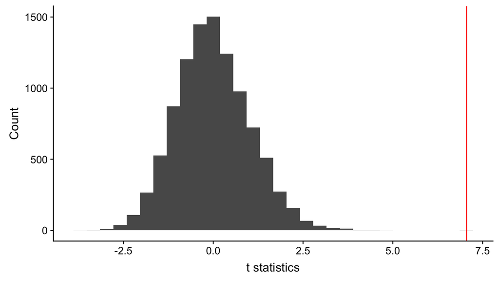

## Age predicted by nose coloration

```r
2 * mean(t_stats >= t_stats[1])
```

```
## [1] 2e-04
```

Note sign of the inequality: how often does the randomized age data give a *larger* *t* statistic than the observed?

Why 2 x 10<sup>-4</sup>?

## Horned lizard predation

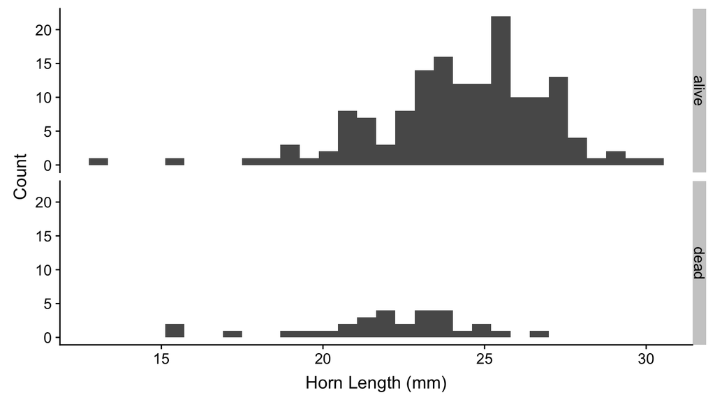

## Horned lizard predation

```r
t_obs <- t.test(horn_length ~ group, data = HornedLizards)
t_obs
```

```
##
##  Welch Two Sample t-test
##
## data:  horn_length by group
## t = 4.2634, df = 40.372, p-value = 0.0001178
## alternative hypothesis: true difference in means is not equal to 0
## 95 percent confidence interval:
##  1.207092 3.381912
## sample estimates:
## mean in group alive  mean in group dead
##            24.28117            21.98667
```

## Horned lizard predation

```r
set.seed(928374)
nreps <- 1e4
t_stats <- numeric(nreps)
t_stats[1] <- t_obs$statistic

for (i in 2:nreps) {
  Rand_group <- sample(HornedLizards$group)
  t_stats[i] <- t.test(horn_length ~ Rand_group,
                       data = HornedLizards)$statistic
}
```

## Horned lizard predation

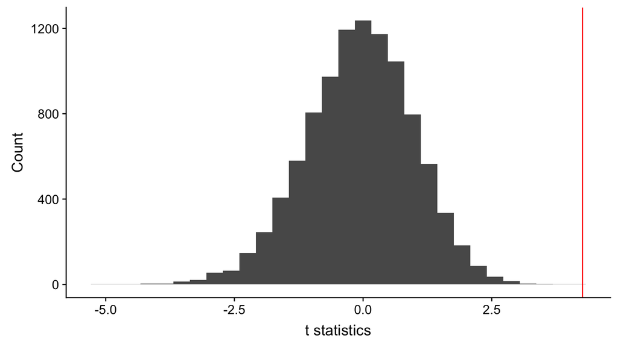

## Horned lizard predation

```r
2 * mean(t_stats >= t_stats[1])
```

```
## [1] 2e-04
```

## Iterations vs. *P*

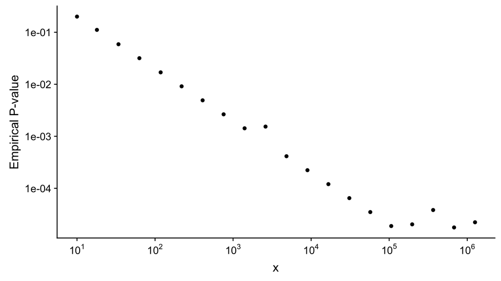

What is the minimal detectable *P* for *n* iterations?

## Empirical *P* vs. Iterations

|  | nreps | P | min_P |
| --- | --- | --- | --- |
| 2 | 18 | 0.1111111 | 0.1111111 |
| 4 | 63 | 0.0317460 | 0.0317460 |
| 6 | 219 | 0.0091324 | 0.0091324 |
| 8 | 756 | 0.0026455 | 0.0026455 |
| 10 | 2604 | 0.0015361 | 0.0007680 |
| 12 | 8966 | 0.0002231 | 0.0002231 |
| 14 | 30865 | 0.0000648 | 0.0000648 |
| 16 | 106246 | 0.0000188 | 0.0000188 |
| 18 | 365727 | 0.0000383 | 0.0000055 |
| 20 | 1258925 | 0.0000222 | 0.0000016 |

## Non-parametric tests

Non-parametric tests often used when data do not meet the assumptions of a traditional (parametric) test:

- One-sample *t*-test \(\rightarrow\) Sign test, Wilcoxon test
- Two-sample *t*-test \(\rightarrow\) Mann-Whitney test
- ANOVA \(\rightarrow\) Kruskal-Wallis

Small sample size, non-normality, unequal variances

**Dramatically lower power compared to a parametric test**

## Randomization as an alternative

For all practical cases, randomization is a better alternative

- Increased power
- No reliance on asymptotic properties of tests
- More relaxed assumptions

## Quiz 10-2

Lecture 10-3